# Лабораторная работа №14

Программирование в командном процессоре ОС UNIX. Расширенное программирование

Иванова Анастасия Сергеевна

1132250427@rudn.ru

Российский университет дружбы народов

2026-05-12

# Докладчик

- Иванова Анастасия Сергеевна
- 1 курс группа НКАбд-07-25
- Российский университет дружбы народов
- 1132250427@rudn.ru

# **Вводная часть**

## Актуальность темы

- Расширенное программирование в bash позволяет решать сложные задачи автоматизации
- Механизмы синхронизации процессов необходимы при разработке многопоточных скриптов
- Создание аналогов системных утилит (man) углубляет понимание работы ОС
- Генерация случайных данных полезна для тестирования и моделирования

## Объект и предмет исследования

**Объект исследования:** - Командный процессор bash - Механизмы синхронизации процессов (файловые блокировки) - Встроенные переменные и функции оболочки

**Предмет исследования:** - Реализация семафоров на уровне файловой системы - Создание аналога команды man - Генерация случайных последовательностей с использованием `$RANDOM` - Взаимодействие между несколькими процессами

## Цели

- Изучить основы программирования в оболочке ОС UNIX
- Научиться писать более сложные командные файлы с использованием логических управляющих конструкций и циклов

# **Выполнение лабораторной работы**

## **Задание 1. Реализация упрощённого механизма семафоров**

### Создание файла `semafor.sh`

```bash
nano semafor.sh
```

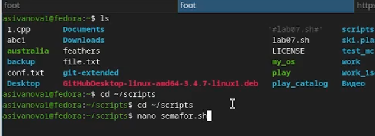

Рисунок 1: Создание файла semafor.sh

### Листинг `semafor.sh`

```bash
#!/bin/bash

LOCK_FILE="/tmp/semaphore.lock"
t1=5
t2=3

while true; do
    if ln "$LOCK_FILE" "$LOCK_FILE.lock" 2>/dev/null; then
        echo "$$: ресурс захвачен, использую в течение $t2 секунд"
        sleep $t2
        rm "$LOCK_FILE.lock"
        echo "$$: ресурс освобождён"
        break
    else
        echo "$$: ресурс занят, ожидаю $t1 секунд"
        sleep $t1
    fi
done
```

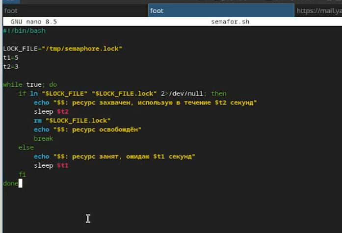

### Делаем скрипт исполняемым

```bash
chmod +x semafor.sh
```

### Тестирование работы семафора

**Терминал 1:**

```bash
./semafor.sh
```

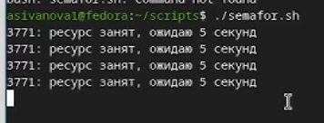

Рисунок 4: Тестирование семафора терминал 1

**Терминал 2 (фоновый запуск с перенаправлением вывода):**

```bash
./semafor.sh > /dev/tty1 &
```

[figure not shown]

## **Задание 2. Реализация команды man**

### Создание файла `my_man.sh`

```bash
nano my_man.sh
```

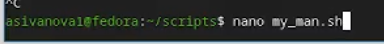

Рисунок 6: Создание файла my_man.sh

### Листинг `my_man.sh`

```bash
#!/bin/bash

if [ $# -ne 1 ]; then
    echo "Использование: $0 <команда>"
    exit 1
fi

CMD="$1"
MAN_FILE="/usr/share/man/man1/${CMD}.1.gz"

if [ -f "$MAN_FILE" ]; then
    zcat "$MAN_FILE" | less
else
    echo "Справка для команды '$CMD' не найдена"
    exit 1
fi
```

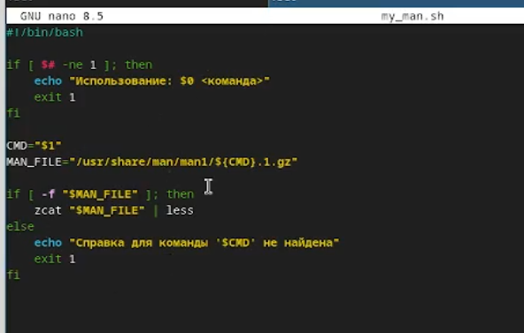

Рисунок 7: Листинг my_man.sh

### Делаем скрипт исполняемым

```bash
chmod +x my_man.sh
```

### Тестирование работы `my_man.sh`

```bash
./my_man.sh ls
./my_man.sh unknown_command
```

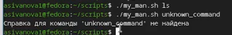

Рисунок 9: Тестирование my_man.sh

## **Задание 3. Генерация случайной последовательности букв**

### Создание файла `random_letters.sh`

```bash
nano random_letters.sh
```

### Листинг `random_letters.sh`

```bash
#!/bin/bash

LENGTH=${1:-20}

for ((i=0; i<LENGTH; i++)); do
    RAND=$((RANDOM % 26))
    LETTER=$(printf \\$(printf '%03o' $((97 + RAND))))
    echo -n "$LETTER"
done
echo
```

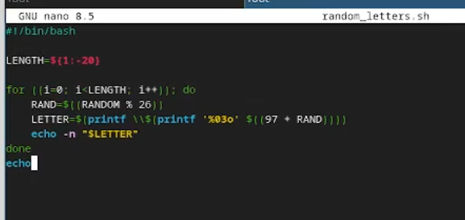

Рисунок 11: Листинг random_letters.sh

### Делаем скрипт исполняемым

```bash
chmod +x random_letters.sh
```

[figure not shown]

Рисунок 12: Изменение прав доступа

### Тестирование работы `random_letters.sh`

```bash
./random_letters.sh
./random_letters.sh 10
```

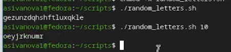

Рисунок 13: Тестирование random_letters.sh

# **Контрольные вопросы**

**1. Найдите синтаксическую ошибку в следующей строке:**

```bash
while [$1 != "exit"]
```

**Ответ:** пропущены пробелы после `[` и перед `]`. Правильно: `while [ "$1" != "exit" ]`

**2. Как объединить (конкатенация) несколько строк в одну?** **Ответ:** можно использовать оператор `+=`:

```bash
str="Hello"
str+=" World"
```

**3. Найдите информацию об утилите seq. Какими иными способами можно реализовать её функционал?** **Ответ:** `seq` генерирует последовательность чисел. Альтернативы:

```bash
for i in {1..10}; do echo $i; done
for ((i=1; i<=10; i++)); do echo $i; done
```

**4. Какой результат даст вычисление выражения `$((10/3))`?** **Ответ:** `3` (целочисленное деление).

**5. Укажите кратко основные отличия командной оболочки zsh от bash.** **Ответ:** zsh имеет автодополнение с подсветкой, поддержку ассоциативных массивов, разделяемые истории между сеансами.

**6. Проверьте, верен ли синтаксис данной конструкции:**

```bash
for ((a=1; a <= LIMIT; a++))
```

**Ответ:** синтаксис верен.

**7. Сравните язык bash с какими-либо языками программирования. Какие преимущества у bash по сравнению с ними? Какие недостатки?** **Ответ:**  
*Преимущества:* простота автоматизации команд ОС, встроенные инструменты для работы с файлами и процессами.  
*Недостатки:* медленная работа, ограниченная поддержка чисел с плавающей точкой.

# **Вывод**

В ходе лабораторной работы были разработаны три скрипта:

- `semafor.sh` – реализация упрощённого механизма семафоров с использованием файловой блокировки.
- `my_man.sh` – аналог команды `man` для просмотра справки из `/usr/share/man/man1`.
- `random_letters.sh` – генерация случайной последовательности букв латинского алфавита с использованием `$RANDOM`.

Приобретены навыки межпроцессного взаимодействия через файловые блокировки, работы со сжатыми man-страницами (`zcat`), генерации случайных последовательностей, а также изучены особенности синтаксиса bash.